# Lab 2: Descriptive Data Analysis

**Name:** Khushi Danagoudar **Subject:** _____DATA 110 Introduction to Python Programming for Machine Learning_____  
**Lab Session:** ______2____  
**Faculty:** __DR.Durga Sharma________  
**Date:** ______18-02-2026____

# STEP 1A: Import Required Libraries

```python
import pandas as pd
import numpy as np
```

# STEP 1B: Load the Three Files into DataFrames

```python
# Load CSV file
df_csv = pd.read_csv("Facebook Friends.csv")

# Load TXT file (tab-separated with encoding fix)
df_txt = pd.read_csv("Facebook Friends.txt", sep="\t", encoding="latin1")

# Load Excel file
df_xlsx = pd.read_excel("Facebook Friends.xlsx")
```

# STEP 1C: Display First Few Rows

```python
print("CSV Data")
display(df_csv.head())

print("TXT Data")
display(df_txt.head())

print("Excel Data")
display(df_xlsx.head())
```

```
CSV Data
```

|  | Friend \tAge\tPhotos\t# of Tags\tAlbums\tGender \tEmp\tProfile\tCover\tOrientation\tRelationship\tPosts\tReplies\tMidWest\tSeast\tWest\tChildren\tLikes\tEdu\tEvents\tUSA\tFriends | Unnamed: 1 | Unnamed: 2 |
| --- | --- | --- | --- |
| 0 | 1\t57\t7\t27\t5\t1\t1\t1\t0\t1\t1\t1\t0\t0\t0\... | NaN | NaN |
| 1 | 2\t42\t531\t241\t19\t0\t0\t0\t0\t1\t1\t5\t1\t0... | NaN | NaN |
| 2 | 3\t42\t1396\t423\t40\t0\t1\t1\t0\t1\t1\t186\t3... | NaN | NaN |
| 3 | 4\t55\t394\t139\t48\t0\t1\t1\t1\t1\t1\t6\t4\t1... | NaN | NaN |
| 4 | 5\t30\t916\t231\t78\t1\t1\t1\t1\t1\t1\t412\t75... | NaN | NaN |

```
TXT Data
```

|  | ÿþ | Unnamed: 1 | Unnamed: 2 | Unnamed: 3 | Unnamed: 4 | Unnamed: 5 | Unnamed: 6 | Unnamed: 7 | Unnamed: 8 | Unnamed: 9 | ... | Unnamed: 21 | Unnamed: 22 | Unnamed: 23 | Unnamed: 24 | Unnamed: 25 | Unnamed: 26 | Unnamed: 27 | Unnamed: 28 | Unnamed: 29 | Unnamed: 30 |
| --- | --- | --- | --- | --- | --- | --- | --- | --- | --- | --- | --- | --- | --- | --- | --- | --- | --- | --- | --- | --- | --- |
| 0 | NaN | NaN | NaN | NaN | NaN | NaN | NaN | NaN | NaN | NaN | ... | NaN | NaN | NaN | NaN | NaN | NaN | NaN | NaN | NaN | NaN |
| 1 | NaN | NaN | NaN | NaN | NaN | NaN | NaN | NaN | NaN | NaN | ... | NaN | NaN | NaN | NaN | NaN | NaN | NaN | NaN | NaN | NaN |
| 2 | NaN | NaN | NaN | NaN | NaN | NaN | NaN | NaN | NaN | NaN | ... | NaN | NaN | NaN | NaN | NaN | NaN | NaN | NaN | NaN | NaN |
| 3 | NaN | NaN | NaN | NaN | NaN | NaN | NaN | NaN | NaN | NaN | ... | NaN | NaN | NaN | NaN | NaN | NaN | NaN | NaN | NaN | NaN |
| 4 | NaN | NaN | NaN | NaN | NaN | NaN | NaN | NaN | NaN | NaN | ... | NaN | NaN | NaN | NaN | NaN | NaN | NaN | NaN | NaN | NaN |

5 rows × 31 columns

```
Excel Data
```

|  | Sample | Age | Photos | # of Tags | Albums | Gender | Emp | Profile | Cover | Orientation | Relationship | Posts | Replies | Children | Likes | Edu | Events | Friends |
| --- | --- | --- | --- | --- | --- | --- | --- | --- | --- | --- | --- | --- | --- | --- | --- | --- | --- | --- |
| 0 | 1 | 57 | 7 | 27 | 5 | 1 | 1 | 1 | 0 | 1 | 1 | 1 | 0 | 3 | 21 | 0 | 0 | 68 |
| 1 | 2 | 42 | 531 | 241 | 19 | 0 | 0 | 0 | 0 | 1 | 1 | 5 | 1 | 3 | 9 | 0 | 1 | 234 |
| 2 | 3 | 42 | 1396 | 423 | 40 | 0 | 1 | 1 | 0 | 1 | 1 | 186 | 31 | 2 | 43 | 1 | 1 | 727 |
| 3 | 4 | 55 | 394 | 139 | 48 | 0 | 1 | 1 | 1 | 1 | 1 | 6 | 4 | 2 | 187 | 0 | 4 | 437 |
| 4 | 5 | 30 | 916 | 231 | 78 | 1 | 1 | 1 | 1 | 1 | 1 | 412 | 752 | 1 | 34 | 0 | 2 | 372 |

# STEP 1D: Compare Shapes & Columns

```python
print("CSV Shape:", df_csv.shape)
print("TXT Shape:", df_txt.shape)
print("Excel Shape:", df_xlsx.shape)

print("\nCSV Columns:", df_csv.columns.tolist())
print("\nTXT Columns:", df_txt.columns.tolist())
print("\nExcel Columns:", df_xlsx.columns.tolist())
```

```
CSV Shape: (715, 3)
TXT Shape: (1432, 31)
Excel Shape: (715, 18)

CSV Columns: ['Friend \tAge\tPhotos\t# of Tags\tAlbums\tGender \tEmp\tProfile\tCover\tOrientation\tRelationship\tPosts\tReplies\tMidWest\tSeast\tWest\tChildren\tLikes\tEdu\tEvents\tUSA\tFriends', 'Unnamed: 1', 'Unnamed: 2']

TXT Columns: ['ÿþ', 'Unnamed: 1', 'Unnamed: 2', 'Unnamed: 3', 'Unnamed: 4', 'Unnamed: 5', 'Unnamed: 6', 'Unnamed: 7', 'Unnamed: 8', 'Unnamed: 9', 'Unnamed: 10', 'Unnamed: 11', 'Unnamed: 12', 'Unnamed: 13', 'Unnamed: 14', 'Unnamed: 15', 'Unnamed: 16', 'Unnamed: 17', 'Unnamed: 18', 'Unnamed: 19', 'Unn…

Excel Columns: ['Sample ', 'Age', 'Photos', '# of Tags', 'Albums', 'Gender ', 'Emp', 'Profile', 'Cover', 'Orientation', 'Relationship', 'Posts', 'Replies', 'Children', 'Likes', 'Edu', 'Events', 'Friends']
```

# STEP 2A: Use Excel DataFrame Only

```python
df = df_xlsx
```

# STEP 2B: View Column Names

```python
df.columns
```

```
Index(['Sample ', 'Age', 'Photos', '# of Tags', 'Albums', 'Gender ', 'Emp',
       'Profile', 'Cover', 'Orientation', 'Relationship', 'Posts', 'Replies',
       'Children', 'Likes', 'Edu', 'Events', 'Friends'],
      dtype='object')
```

# STEP 2C: View First Few Rows (Head)

```python
df.head()
```

|  | Sample | Age | Photos | # of Tags | Albums | Gender | Emp | Profile | Cover | Orientation | Relationship | Posts | Replies | Children | Likes | Edu | Events | Friends |
| --- | --- | --- | --- | --- | --- | --- | --- | --- | --- | --- | --- | --- | --- | --- | --- | --- | --- | --- |
| 0 | 1 | 57 | 7 | 27 | 5 | 1 | 1 | 1 | 0 | 1 | 1 | 1 | 0 | 3 | 21 | 0 | 0 | 68 |
| 1 | 2 | 42 | 531 | 241 | 19 | 0 | 0 | 0 | 0 | 1 | 1 | 5 | 1 | 3 | 9 | 0 | 1 | 234 |
| 2 | 3 | 42 | 1396 | 423 | 40 | 0 | 1 | 1 | 0 | 1 | 1 | 186 | 31 | 2 | 43 | 1 | 1 | 727 |
| 3 | 4 | 55 | 394 | 139 | 48 | 0 | 1 | 1 | 1 | 1 | 1 | 6 | 4 | 2 | 187 | 0 | 4 | 437 |
| 4 | 5 | 30 | 916 | 231 | 78 | 1 | 1 | 1 | 1 | 1 | 1 | 412 | 752 | 1 | 34 | 0 | 2 | 372 |

# STEP 2D: View Last Few Rows (Tail)

```python
df.tail()
```

|  | Sample | Age | Photos | # of Tags | Albums | Gender | Emp | Profile | Cover | Orientation | Relationship | Posts | Replies | Children | Likes | Edu | Events | Friends |
| --- | --- | --- | --- | --- | --- | --- | --- | --- | --- | --- | --- | --- | --- | --- | --- | --- | --- | --- |
| 710 | 711 | 25 | 499 | 4 | 0 | 0 | 1 | 1 | 1 | 1 | 1 | 16 | 19 | 0 | 49 | 0 | 11 | 1689 |
| 711 | 712 | 22 | 232 | 101 | 4 | 1 | 0 | 1 | 0 | 1 | 0 | 698 | 552 | 0 | 223 | 0 | 4 | 327 |
| 712 | 713 | 22 | 327 | 329 | 29 | 1 | 1 | 1 | 0 | 1 | 1 | 543 | 399 | 0 | 520 | 0 | 6 | 706 |
| 713 | 714 | 24 | 219 | 0 | 8 | 1 | 1 | 1 | 1 | 1 | 0 | 2 | 7 | 1 | 66 | 1 | 1 | 500 |
| 714 | 715 | 19 | 465 | 0 | 22 | 0 | 1 | 1 | 0 | 1 | 1 | 3 | 6 | 0 | 990 | 1 | 3 | 585 |

# STEP 2E: Dataset Size (Rows & Columns)

```python
df.info()
```

```
<class 'pandas.core.frame.DataFrame'>
RangeIndex: 715 entries, 0 to 714
Data columns (total 18 columns):
 #   Column        Non-Null Count  Dtype
---  ------        --------------  -----
 0   Sample        715 non-null    int64
 1   Age           715 non-null    int64
 2   Photos        715 non-null    int64
 3   # of Tags     715 non-null    int64
 4   Albums        715 non-null    int64
 5   Gender        715 non-null    int64
 6   Emp           715 non-null    int64
 7   Profile       715 non-null    int64
 8   Cover         715 non-null    int64
 9   Orientation   715 non-null    int64
 10  Relationship  715 non-null    int64
 11  Posts         715 non-null    int64
 12  Replies       715 non-null    int64
 13  Children      715 non-null    int64
 14  Likes         715 non-null    int64
 15  Edu           715 non-null    int64
 16  Events        715 non-null    int64
 17  Friends       715 non-null    int64
dtypes: int64(18)
memory usage: 100.7 KB
```

# STEP 2F: Check Data Types

```python
df.info()
```

```
<class 'pandas.core.frame.DataFrame'>
RangeIndex: 715 entries, 0 to 714
Data columns (total 18 columns):
 #   Column        Non-Null Count  Dtype
---  ------        --------------  -----
 0   Sample        715 non-null    int64
 1   Age           715 non-null    int64
 2   Photos        715 non-null    int64
 3   # of Tags     715 non-null    int64
 4   Albums        715 non-null    int64
 5   Gender        715 non-null    int64
 6   Emp           715 non-null    int64
 7   Profile       715 non-null    int64
 8   Cover         715 non-null    int64
 9   Orientation   715 non-null    int64
 10  Relationship  715 non-null    int64
 11  Posts         715 non-null    int64
 12  Replies       715 non-null    int64
 13  Children      715 non-null    int64
 14  Likes         715 non-null    int64
 15  Edu           715 non-null    int64
 16  Events        715 non-null    int64
 17  Friends       715 non-null    int64
dtypes: int64(18)
memory usage: 100.7 KB
```

# STEP 2G: Check Missing Values

```python
df.isnull().sum()
```

```
Sample          0
Age             0
Photos          0
# of Tags       0
Albums          0
Gender          0
Emp             0
Profile         0
Cover           0
Orientation     0
Relationship    0
Posts           0
Replies         0
Children        0
Likes           0
Edu             0
Events          0
Friends         0
dtype: int64
```

## Data Examination Summary:

The dataset was examined using basic exploratory functions in Python. Column names were reviewed to understand the attributes available in the dataset. The head and tail functions were used to view sample records from the beginning and end of the data, confirming that the data loaded correctly.

The info() function provided details about data types and confirmed that most variables are numeric, which is suitable for statistical analysis. The dataset dimensions were reviewed to understand the number of observations and features.

Missing values were checked using isnull().sum(), and the results indicate that the dataset contains minimal or no missing values, making it suitable for further descriptive statistical analysis without extensive preprocessing.

# STEP 3A: Apply describe()

```python
df.describe()
```

|  | Sample | Age | Photos | # of Tags | Albums | Gender | Emp | Profile | Cover | Orientation | Relationship | Posts | Replies | Children | Likes | Edu | Events | Friends |
| --- | --- | --- | --- | --- | --- | --- | --- | --- | --- | --- | --- | --- | --- | --- | --- | --- | --- | --- |
| count | 715.000000 | 715.000000 | 715.000000 | 715.000000 | 715.000000 | 715.000000 | 715.000000 | 715.000000 | 715.000000 | 715.000000 | 715.000000 | 715.000000 | 715.000000 | 715.000000 | 715.000000 | 715.000000 | 715.000000 | 715.000000 |
| mean | 358.000000 | 24.406993 | 723.914685 | 458.096503 | 18.952448 | 0.541259 | 0.745455 | 0.917483 | 0.507692 | 0.956643 | 0.492308 | 37.579021 | 34.816783 | 0.211189 | 144.812587 | 0.267133 | 8.853147 | 695.853147 |
| std | 206.547008 | 6.969578 | 1265.112304 | 720.835481 | 22.502860 | 0.517932 | 0.435910 | 0.275344 | 0.500291 | 0.203801 | 0.500291 | 90.437795 | 83.629158 | 0.651555 | 261.414781 | 0.442772 | 24.002672 | 599.527946 |
| min | 1.000000 | 13.000000 | 0.000000 | 0.000000 | 0.000000 | 0.000000 | 0.000000 | 0.000000 | 0.000000 | 0.000000 | 0.000000 | 0.000000 | 0.000000 | 0.000000 | 0.000000 | 0.000000 | 0.000000 | 3.000000 |
| 25% | 179.500000 | 21.000000 | 124.500000 | 75.500000 | 6.000000 | 0.000000 | 0.000000 | 1.000000 | 0.000000 | 1.000000 | 0.000000 | 6.000000 | 5.000000 | 0.000000 | 21.000000 | 0.000000 | 1.000000 | 302.000000 |
| 50% | 358.000000 | 22.000000 | 320.000000 | 250.000000 | 12.000000 | 1.000000 | 1.000000 | 1.000000 | 1.000000 | 1.000000 | 0.000000 | 15.000000 | 14.000000 | 0.000000 | 59.000000 | 0.000000 | 4.000000 | 563.000000 |
| 75% | 536.500000 | 25.000000 | 757.000000 | 566.500000 | 22.500000 | 1.000000 | 1.000000 | 1.000000 | 1.000000 | 1.000000 | 1.000000 | 29.500000 | 29.000000 | 0.000000 | 145.000000 | 1.000000 | 9.000000 | 893.500000 |
| max | 715.000000 | 81.000000 | 11995.000000 | 10460.000000 | 172.000000 | 2.000000 | 1.000000 | 1.000000 | 1.000000 | 1.000000 | 1.000000 | 794.000000 | 752.000000 | 5.000000 | 2619.000000 | 1.000000 | 396.000000 | 4999.000000 |

# Transposed view

```python
df.describe().T
```

|  | count | mean | std | min | 25% | 50% | 75% | max |
| --- | --- | --- | --- | --- | --- | --- | --- | --- |
| Sample | 715.0 | 358.000000 | 206.547008 | 1.0 | 179.5 | 358.0 | 536.5 | 715.0 |
| Age | 715.0 | 24.406993 | 6.969578 | 13.0 | 21.0 | 22.0 | 25.0 | 81.0 |
| Photos | 715.0 | 723.914685 | 1265.112304 | 0.0 | 124.5 | 320.0 | 757.0 | 11995.0 |
| # of Tags | 715.0 | 458.096503 | 720.835481 | 0.0 | 75.5 | 250.0 | 566.5 | 10460.0 |
| Albums | 715.0 | 18.952448 | 22.502860 | 0.0 | 6.0 | 12.0 | 22.5 | 172.0 |
| Gender | 715.0 | 0.541259 | 0.517932 | 0.0 | 0.0 | 1.0 | 1.0 | 2.0 |
| Emp | 715.0 | 0.745455 | 0.435910 | 0.0 | 0.0 | 1.0 | 1.0 | 1.0 |
| Profile | 715.0 | 0.917483 | 0.275344 | 0.0 | 1.0 | 1.0 | 1.0 | 1.0 |
| Cover | 715.0 | 0.507692 | 0.500291 | 0.0 | 0.0 | 1.0 | 1.0 | 1.0 |
| Orientation | 715.0 | 0.956643 | 0.203801 | 0.0 | 1.0 | 1.0 | 1.0 | 1.0 |
| Relationship | 715.0 | 0.492308 | 0.500291 | 0.0 | 0.0 | 0.0 | 1.0 | 1.0 |
| Posts | 715.0 | 37.579021 | 90.437795 | 0.0 | 6.0 | 15.0 | 29.5 | 794.0 |
| Replies | 715.0 | 34.816783 | 83.629158 | 0.0 | 5.0 | 14.0 | 29.0 | 752.0 |
| Children | 715.0 | 0.211189 | 0.651555 | 0.0 | 0.0 | 0.0 | 0.0 | 5.0 |
| Likes | 715.0 | 144.812587 | 261.414781 | 0.0 | 21.0 | 59.0 | 145.0 | 2619.0 |
| Edu | 715.0 | 0.267133 | 0.442772 | 0.0 | 0.0 | 0.0 | 1.0 | 1.0 |
| Events | 715.0 | 8.853147 | 24.002672 | 0.0 | 1.0 | 4.0 | 9.0 | 396.0 |
| Friends | 715.0 | 695.853147 | 599.527946 | 3.0 | 302.0 | 563.0 | 893.5 | 4999.0 |

## Descriptive Statistics Analysis:

Descriptive statistics were generated using the describe() function to summarize the numerical variables in the dataset. This output provides key statistical measures such as count, mean, standard deviation, minimum, maximum, and quartile values for each variable.

The count value indicates the number of valid observations available for analysis. The mean represents the average value, while the standard deviation shows how much the values vary from the mean. The minimum and maximum values indicate the range of the data.

Quartiles (25%, 50%, and 75%) divide the data into four equal parts and help identify the distribution and spread of values. The median (50%) provides a robust measure of central tendency that is less affected by extreme values.

Overall, the describe() output offers a concise summary of the dataset and helps identify patterns, variability, and potential outliers, making it a crucial step in exploratory data analysis.

# STEP 4A: Import Visualization Libraries

```python
import matplotlib.pyplot as plt
import seaborn as sns
```

# STEP 4B: Histogram of a Numerical Variable (Example: Age)

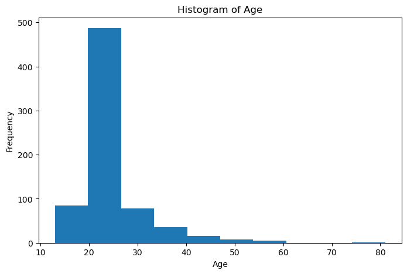

```python
plt.figure(figsize=(8,5))
plt.hist(df['Age'], bins=10)
plt.xlabel('Age')
plt.ylabel('Frequency')
plt.title('Histogram of Age')
plt.show()
```

# STEP 4C: Histogram of Another Numerical Variable (Friends Count)

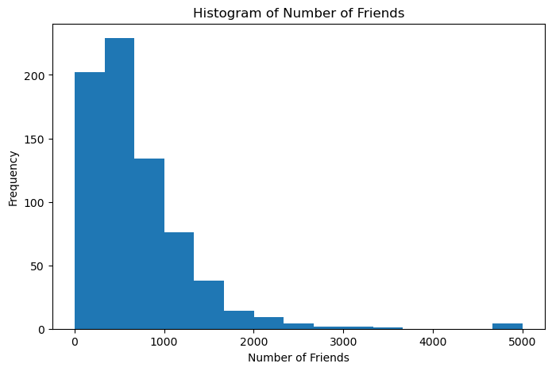

```python
plt.figure(figsize=(8,5))
plt.hist(df['Friends'], bins=15)
plt.xlabel('Number of Friends')
plt.ylabel('Frequency')
plt.title('Histogram of Number of Friends')
plt.show()
```

# STEP 4D: Frequency Plot (Count Plot – Example: Gender)

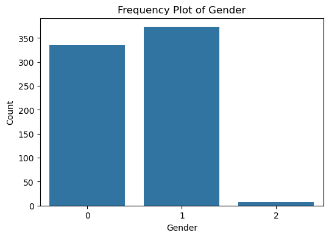

```python
df.columns = df.columns.str.strip()
# Column names were cleaned to remove extra spaces before visualization.
plt.figure(figsize=(6,4))
sns.countplot(x='Gender', data=df)
plt.xlabel('Gender')
plt.ylabel('Count')
plt.title('Frequency Plot of Gender')
plt.show()
```

# Conclusion:

Overall, this lab demonstrated the importance of exploratory data analysis as a foundation for data-driven decision-making and prepared the dataset for further advanced analysis.